# Module 3: Analyzing text content with natural language processing

Lesson 3.2: Part-of-speech and named entity recognition  
AI-aided content analysis of sustainability communication

nils.holmberg@iko.lu.se

## Token Relationships and Knowledge Graphs

- Tokens form the building blocks of text relationships and meaning in NLP.
- Aspect-based sentiment analysis identifies sentiment tied to specific aspects or topics.
- Knowledge graphs map relationships between entities to provide contextual insights.
- Token relationships enhance machine understanding of complex linguistic structures.
- These concepts drive applications in sentiment analysis, recommendations, and chatbots.

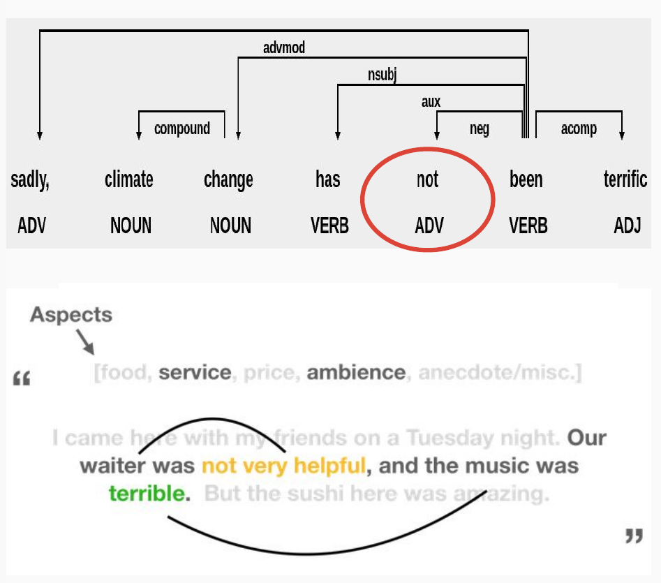

## Units of NLP Analysis

- NLP processes text at various levels: texts, paragraphs, sentences, words, and tokens.
- Texts provide overarching narratives; tokens are the smallest meaningful units.
- Paragraphs and sentences act as natural segmentation points for processing.
- Tokens are annotated with attributes like part-of-speech and syntactic role.
- Understanding these units is key to granular and scalable text analysis.

## Applying SpaCy NLP Models to Dataframes

- SpaCy provides pre-trained NLP models for efficient text processing.
- Text and sentence dataframes integrate structured data with NLP outputs.
- NLP models parse and enrich text with token, dependency, and entity annotations.
- Batch processing of text improves efficiency for large datasets.
- Practical applications include text classification, summarization, and sentiment analysis.

## Iterating Over Sentence Dataframes and SpaCy Documents

- Sentence-level dataframes organize text into manageable units for analysis.
- SpaCy document objects provide linguistic annotations for each token.
- Iterating enables extraction of sentence-specific attributes like entities or sentiments.
- Combines structured data analysis with NLP insights for robust results.
- Streamlines processes such as summarization, search indexing, and context identification.

## Text Normalization and Token Attributes

- Normalization reduces text variability by standardizing tokens.
- Lemmatization extracts the base form of words for consistent analysis.
- Token attributes, such as text and lemma, enable detailed linguistic understanding.
- Improved token consistency enhances downstream NLP tasks like matching and clustering.
- Normalization is essential for multilingual and noisy text processing.

## Infering Named Entity Recognition (NER)

- NER identifies and categorizes entities like names, organizations, and dates.
- Extracted entities provide structured insights from unstructured text.
- Applications include content categorization, fraud detection, and customer sentiment analysis.
- NER supports personalized recommendations and enhanced search capabilities.
- It is fundamental to building knowledge graphs and question-answering systems.

## Infering Part-of-Speech Tagging (POS)

- POS tagging assigns grammatical roles to tokens like nouns, verbs, and adjectives.
- Captures the syntactic structure of text for deeper linguistic understanding.
- Applications include syntax parsing, machine translation, and text generation.
- POS tagging enhances accuracy in sentiment analysis and topic modeling.
- Supports advanced NLP tasks like dependency parsing and coreference resolution.